# Evaluating Asteroid Characteristics and Predicting Hazard Levels Using NASA’s Asteroid Classification Dataset

Vishal Bakshi, Pratiksha Dange, Sudanshu Dotel, Qibin Huang

2023-11-01

**1. Neo Reference ID:** ID for the Asteroid

**2. Name:** Name of the Asteroid

**3. Absolute Magnitude:** Indicates the brightness of the asteroid; lower magnitude means a brighter star, higher magnitude means a dimmer star.

**4. Est Dia in KM (min):** Estimated minimum size of the asteroid in kilometers.

**5. Est Dia in KM (max):** Estimated maximum size of the asteroid in kilometers.

**6. Relative Velocity (km per sec):** The velocity of the asteroid.

**7. Orbit Uncertainty Minimum:** A measure of the uncertainty in the asteroid’s orbit.

**8. Jupiter Tisserand Invariant:** The JTI measures the influence of Jupiter’s gravitational pull on celestial bodies; lower JTI values are farther from Jupiter.

**9. Eccentricity:** Determines the shape of the orbit; 0 < E < 1 indicates an ellipse, E = 1 is a parabola, and E > 1 is a hyperbola.

**10. Semi Major Axis:** Indicates the size of the asteroid’s orbit.

**11. Inclination:** Denotes the tilt of the asteroid’s orbit.

**12. Perihelion Distance:** Indicates how close the asteroid gets to the Sun during its orbit.

**13. Aphelion Dist:** Specifies how far the asteroid is from the Sun during its orbit.

**14. Perihelion Time:** The time when the asteroid is closest to the Sun.

**15. Mean Motion:** Provides information about how the asteroid moves in its orbit.

**16. Hazardous:** Target variable indicating whether the asteroid is considered hazardous to Earth; 1 for hazardous, 0 for not hazardous.

## Importing Dataset

```r
current_directory <- getwd()
data_path <- "Datasets/Asteroid_Hazard_Classification.csv"
file_path <- file.path(dirname(current_directory), data_path)
Ast_raw <- data.frame(read.csv(file_path))

kable(summary(Ast_raw), "html") %>%
  kable_styling(full_width = FALSE) %>%
  scroll_box(width = "100%", height = "400px")
```

|  | Neo.Reference.ID | Name | Absolute.Magnitude | Est.Dia.in.KM.min. | Est.Dia.in.KM.max. | Est.Dia.in.Feet.min. | Est.Dia.in.Feet.max. | Close.Approach.Date | Epoch.Date.Close.Approach | Relative.Velocity.km.per.sec | Miss.Dist..Astronomical. | Miss.Dist..lunar. | Miss.Dist..kilometers. | Orbiting.Body | Orbit.ID | Orbit.Determination.Date | Orbit.Uncertainity | Minimum.Orbit.Intersection | Jupiter.Tisserand.Invariant | Epoch.Osculation | Eccentricity | Semi.Major.Axis | Inclination | Asc.Node.Longitude | Orbital.Period | Perihelion.Distance | Perihelion.Arg | Aphelion.Dist | Perihelion.Time | … |
| --- | --- | --- | --- | --- | --- | --- | --- | --- | --- | --- | --- | --- | --- | --- | --- | --- | --- | --- | --- | --- | --- | --- | --- | --- | --- | --- | --- | --- | --- | --- |
|  | Min. :2000433 | Min. :2000433 | Min. :11.2 | Min. : 0.00 | Min. : 0.0 | Min. : 3 | Min. : 7 | Length:3692 | Min. :7.89e+11 | Min. : 0.3 | Min. :0.000 | Min. : 0.1 | Min. : 26610 | Length:3692 | Min. : 1 | Length:3692 | Min. :0.0 | Min. :0.000 | Min. :2.20 | Min. :2450164 | Min. :0.008 | Min. :0.62 | Min. : 0.0 | Min. : 0 | Min. : 177 | Min. :0.081 | Min. : 0 | Min. :0.80 | Min. :2450100 | … |
|  | 1st Qu.:3127402 | 1st Qu.:3127402 | 1st Qu.:20.1 | 1st Qu.: 0.03 | 1st Qu.: 0.1 | 1st Qu.: 110 | 1st Qu.: 245 | Class :character | 1st Qu.:9.83e+11 | 1st Qu.: 8.3 | 1st Qu.:0.123 | 1st Qu.: 47.8 | 1st Qu.:18385234 | Class :character | 1st Qu.: 9 | Class :character | 1st Qu.:0.0 | 1st Qu.:0.016 | 1st Qu.:3.85 | 1st Qu.:2458000 | 1st Qu.:0.250 | 1st Qu.:1.05 | 1st Qu.: 5.0 | 1st Qu.: 85 | 1st Qu.: 393 | 1st Qu.:0.664 | 1st Qu.: 95 | 1st Qu.:1.32 | 1st Qu.:2457782 | … |
|  | Median :3529614 | Median :3529614 | Median :21.9 | Median : 0.11 | Median : 0.2 | Median : 364 | Median : 813 | Mode :character | Median :1.17e+12 | Median :12.8 | Median :0.258 | Median :100.5 | Median :38651850 | Mode :character | Median : 16 | Mode :character | Median :4.0 | Median :0.050 | Median :4.83 | Median :2458000 | Median :0.384 | Median :1.33 | Median :10.1 | Median :174 | Median : 557 | Median :0.865 | Median :189 | Median :1.78 | Median :2457963 | … |
|  | Mean :3290969 | Mean :3290969 | Mean :22.2 | Mean : 0.21 | Mean : 0.5 | Mean : 684 | Mean : 1531 | NA | Mean :1.16e+12 | Mean :13.9 | Mean :0.253 | Mean : 98.3 | Mean :37784318 | NA | Mean : 28 | NA | Mean :3.7 | Mean :0.086 | Mean :4.87 | Mean :2457689 | Mean :0.395 | Mean :1.47 | Mean :13.3 | Mean :173 | Mean : 686 | Mean :0.837 | Mean :184 | Mean :2.11 | Mean :2457692 | … |
|  | 3rd Qu.:3694459 | 3rd Qu.:3694459 | 3rd Qu.:24.5 | 3rd Qu.: 0.25 | 3rd Qu.: 0.6 | 3rd Qu.: 833 | 3rd Qu.: 1862 | NA | 3rd Qu.:1.34e+12 | 3rd Qu.:18.0 | 3rd Qu.:0.384 | 3rd Qu.:149.2 | 3rd Qu.:57389857 | NA | 3rd Qu.: 30 | NA | 3rd Qu.:7.0 | 3rd Qu.:0.132 | 3rd Qu.:5.78 | 3rd Qu.:2458000 | 3rd Qu.:0.526 | 3rd Qu.:1.82 | 3rd Qu.:19.2 | 3rd Qu.:257 | 3rd Qu.: 894 | 3rd Qu.:1.017 | 3rd Qu.:271 | 3rd Qu.:2.69 | 3rd Qu.:2458113 | … |
|  | Max. :3781897 | Max. :3781897 | Max. :32.1 | Max. :15.58 | Max. :34.8 | Max. :51114 | Max. :114294 | NA | Max. :1.47e+12 | Max. :44.2 | Max. :0.500 | Max. :194.5 | Max. :74781600 | NA | Max. :611 | NA | Max. :9.0 | Max. :0.478 | Max. :9.03 | Max. :2458020 | Max. :0.960 | Max. :5.07 | Max. :75.4 | Max. :360 | Max. :4172 | Max. :1.300 | Max. :360 | Max. :8.98 | Max. :2458839 | … |

## Data Preprocessing

In the data Pre-processing with respect to the dataframe:

Step : 1 : Converting the Hazard column from string to integer, and into categorical.

```r
Ast_raw <- Ast_raw %>%
mutate(Hazardous = as.integer(Hazardous))#(1 is True, 0 is False)
Ast_raw$Hazardous <- as.factor(Ast_raw$Hazardous)
```

Step : 2 : Dropping columns which are not required for our analysis:

```r
# Load required libraries
library(knitr)
library(kableExtra)

selected_columns <- c('Neo.Reference.ID', 'Name', 'Absolute.Magnitude', 'Est.Dia.in.KM.min.', 'Est.Dia.in.KM.max.', 'Relative.Velocity.km.per.sec', 'Orbit.Uncertainity', 'Jupiter.Tisserand.Invariant', 'Eccentricity', 'Semi.Major.Axis', 'Inclination', 'Perihelion.Distance', 'Aphelion.Dist', 'Perihelion.Time', 'Mean.Motion', 'Hazardous')

Ast_Subset <- subset(Ast_raw, select = selected_columns)

# Create a nicely formatted table
kable(Ast_Subset, "html") %>%
  kable_styling(full_width = FALSE) %>%
  scroll_box(width = "100%", height = "400px")
```

| Neo.Reference.ID | Name | Absolute.Magnitude | Est.Dia.in.KM.min. | Est.Dia.in.KM.max. | Relative.Velocity.km.per.sec | Orbit.Uncertainity | Jupiter.Tisserand.Invariant | Eccentricity | Semi.Major.Axis | Inclination | Perihelion.Distance | Aphelion.Dist | Perihelion.Time | Mean.Motion | Hazardous |
| --- | --- | --- | --- | --- | --- | --- | --- | --- | --- | --- | --- | --- | --- | --- | --- |
| 3703080 | 3703080 | 21.6 | 0.127 | 0.284 | 6.116 | 5 | 4.63 | 0.426 | 1.407 | 6.026 | 0.808 | 2.006 | 2458162 | 0.591 | 1 |
| 3723955 | 3723955 | 21.3 | 0.146 | 0.327 | 18.114 | 3 | 5.46 | 0.352 | 1.108 | 28.413 | 0.718 | 1.497 | 2457795 | 0.845 | 0 |
| 2446862 | 2446862 | 20.3 | 0.232 | 0.518 | 7.591 | 0 | 4.56 | 0.348 | 1.459 | 4.238 | 0.951 | 1.967 | 2458120 | 0.559 | 1 |
| 3092506 | 3092506 | 27.4 | 0.009 | 0.020 | 11.174 | 6 | 5.09 | 0.217 | 1.256 | 7.906 | 0.984 | 1.528 | 2457902 | 0.700 | 0 |
| 3514799 | 3514799 | 21.6 | 0.127 | 0.284 | 9.841 | 1 | 5.15 | 0.210 | 1.226 | 16.793 | 0.968 | 1.484 | 2457814 | 0.726 | 1 |
| 3671135 | 3671135 | 19.6 | 0.320 | 0.715 | 10.809 | 1 | 4.72 | 0.563 | 1.324 | 17.928 | 0.578 | 2.069 | 2458009 | 0.647 | 0 |
| 2495323 | 2495323 | 19.6 | 0.320 | 0.715 | 10.809 | 1 | 4.72 | 0.563 | 1.324 | 17.928 | 0.578 | 2.069 | 2458009 | 0.647 | 0 |
| 2153315 | 2153315 | 19.2 | 0.384 | 0.859 | 24.422 | 0 | 4.92 | 0.450 | 1.237 | 34.695 | 0.681 | 1.794 | 2458242 | 0.716 | 0 |
| 2162463 | 2162463 | 17.8 | 0.732 | 1.637 | 17.374 | 0 | 5.39 | 0.238 | 1.146 | 22.215 | 0.873 | 1.418 | 2458222 | 0.804 | 0 |
| 2306383 | 2306383 | 21.5 | 0.133 | 0.298 | 12.900 | 0 | 6.62 | 0.551 | 0.876 | 2.060 | 0.393 | 1.359 | 2457901 | 1.202 | 1 |
| 3444370 | 3444370 | 22.4 | 0.088 | 0.197 | 22.421 | 6 | 7.03 | 0.476 | 0.814 | 23.186 | 0.427 | 1.201 | 2457996 | 1.342 | 0 |
| 3448992 | 3448992 | 25.8 | 0.018 | 0.041 | 17.275 | 4 | 5.12 | 0.205 | 1.241 | 13.744 | 0.987 | 1.495 | 2457935 | 0.713 | 0 |
| 3611400 | 3611400 | 25.0 | 0.027 | 0.059 | 12.119 | 6 | 6.38 | 0.327 | 0.930 | 8.334 | 0.626 | 1.234 | 2457940 | 1.099 | 0 |
| 2162854 | 2162854 | 19.1 | 0.402 | 0.900 | 10.830 | 0 | 4.86 | 0.149 | 1.323 | 21.265 | 1.125 | 1.521 | 2457977 | 0.648 | 0 |
| 3446396 | 3446396 | 18.8 | 0.462 | 1.033 | 39.605 | 0 | 3.24 | 0.861 | 1.983 | 10.023 | 0.275 | 3.690 | 2457894 | 0.353 | 0 |
| 3764806 | 3764806 | 25.2 | 0.024 | 0.054 | 25.211 | 6 | 6.89 | 0.442 | 0.838 | 19.768 | 0.468 | 1.208 | 2457925 | 1.286 | 0 |
| 3314405 | 3314405 | 20.0 | 0.266 | 0.594 | 3.089 | 0 | 3.79 | 0.378 | 1.958 | 5.661 | 1.219 | 2.697 | 2457772 | 0.360 | 0 |
| 3426410 | 3426410 | 21.0 | 0.168 | 0.375 | 20.019 | 1 | 6.47 | 0.453 | 0.908 | 8.279 | 0.497 | 1.319 | 2457969 | 1.139 | 0 |
| 3666785 | 3666785 | 22.3 | 0.092 | 0.206 | 8.526 | 3 | 5.37 | 0.260 | 1.167 | 5.035 | 0.864 | 1.470 | 2457771 | 0.782 | 0 |
| 3702321 | 3702321 | 22.7 | 0.077 | 0.171 | 7.920 | 4 | 6.52 | 0.151 | 0.914 | 5.860 | 0.775 | 1.052 | 2458139 | 1.128 | 0 |
| 3719196 | 3719196 | 26.1 | 0.016 | 0.036 | 4.655 | 5 | 6.36 | 0.171 | 0.939 | 11.948 | 0.778 | 1.100 | 2458043 | 1.083 | 0 |
| 3447920 | 3447920 | 20.6 | 0.202 | 0.451 | 2.164 | 2 | 3.75 | 0.407 | 1.978 | 4.062 | 1.172 | 2.785 | 2457958 | 0.354 | 0 |
| 3005973 | 3005973 | 21.7 | 0.121 | 0.272 | 28.419 | 1 | 6.15 | 0.868 | 0.907 | 4.035 | 0.119 | 1.694 | 2453598 | 1.142 | 1 |
| 3660308 | 3660308 | 23.9 | 0.044 | 0.099 | 10.552 | 3 | 4.77 | 0.399 | 1.358 | 3.854 | 0.816 | 1.899 | 2457913 | 0.623 | 0 |
| 3348144 | 3348144 | 23.9 | 0.044 | 0.099 | 17.565 | 1 | 6.30 | 0.397 | 0.940 | 11.608 | 0.567 | 1.314 | 2458097 | 1.081 | 0 |
| 3646046 | 3646046 | 21.3 | 0.146 | 0.327 | 19.223 | 4 | 5.15 | 0.249 | 1.184 | 35.240 | 0.889 | 1.479 | 2457816 | 0.765 | 1 |
| 3780693 | 3780693 | 27.0 | 0.011 | 0.024 | 7.164 | 7 | 5.87 | 0.318 | 1.034 | 4.008 | 0.706 | 1.363 | 2457902 | 0.937 | 0 |
| 2162173 | 2162173 | 19.3 | 0.367 | 0.820 | 13.576 | 0 | 5.31 | 0.190 | 1.190 | 5.884 | 0.963 | 1.416 | 2457798 | 0.760 | 1 |
| 3092312 | 3092312 | 22.6 | 0.080 | 0.179 | 11.470 | 0 | 5.09 | 0.428 | 1.235 | 5.850 | 0.706 | 1.764 | 2457752 | 0.718 | 0 |
| 3273782 | 3273782 | 23.8 | 0.046 | 0.103 | 11.931 | 0 | 7.48 | 0.386 | 0.763 | 20.834 | 0.468 | 1.058 | 2455988 | 1.479 | 0 |

[output cut: 3662 more lines]

Step : 3 : Outlier Check:

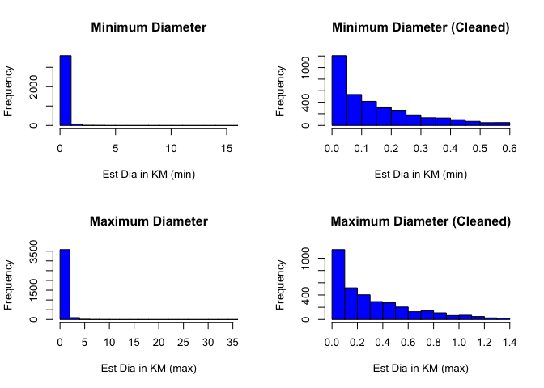

```r
find_outliers <- function(x) {
  q1 <- quantile(x, 0.25)
  q3 <- quantile(x, 0.75)
  iqr <- q3 - q1
  lower_bound <- q1 - 1.5 * iqr
  upper_bound <- q3 + 1.5 * iqr
  return(x[x < lower_bound | x > upper_bound])
}

# Find and remove outliers in the minimum diameter
outliers_min <- find_outliers(Ast_Subset$Est.Dia.in.KM.min.)
data_cleaned_min <- Ast_Subset[!(Ast_Subset$Est.Dia.in.KM.min. %in% outliers_min), ]

# Find and remove outliers in the maximum diameter
outliers_max <- find_outliers(Ast_Subset$Est.Dia.in.KM.max.)
data_cleaned_max <- Ast_Subset[!(Ast_Subset$Est.Dia.in.KM.max. %in% outliers_max), ]

par(mfrow=c(2,2))

hist(Ast_Subset$Est.Dia.in.KM.min., main="Minimum Diameter", xlab="Est Dia in KM (min)", col="blue")
hist(data_cleaned_min$Est.Dia.in.KM.min., main="Minimum Diameter (Cleaned)", xlab="Est Dia in KM (min)", col="blue")

hist(Ast_Subset$Est.Dia.in.KM.max., main="Maximum Diameter", xlab="Est Dia in KM (max)", col="blue")
hist(data_cleaned_max$Est.Dia.in.KM.max., main="Maximum Diameter (Cleaned)", xlab="Est Dia in KM (max)", col="blue")
```

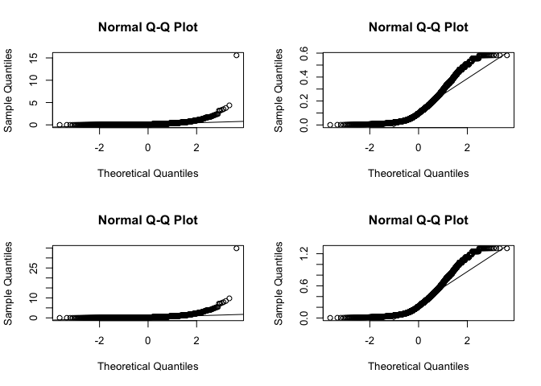

```r
# Q-Q plot for minimum asteroid diameter
#original data
qqnorm(Ast_Subset$Est.Dia.in.KM.min.)
qqline(Ast_Subset$Est.Dia.in.KM.min.)
#clean data
qqnorm(data_cleaned_min$Est.Dia.in.KM.min.)
qqline(data_cleaned_min$Est.Dia.in.KM.min.)


# Q-Q plot for maximum asteroid diameter

#original data
qqnorm(Ast_Subset$Est.Dia.in.KM.max.)
qqline(Ast_Subset$Est.Dia.in.KM.max.)
#clean data
qqnorm(data_cleaned_max$Est.Dia.in.KM.max.)
qqline(data_cleaned_max$Est.Dia.in.KM.max.)
```

```r
shapiro.test(data_cleaned_min$Est.Dia.in.KM.min.)
shapiro.test(data_cleaned_max$Est.Dia.in.KM.max.)

#the p-values for both the minimum and maximum asteroid diameters are less than 2e-16, indicating that the data significantly deviates from a normal distribution.
```

[output not shown]

```r
# Load the ggplot2 package
library(ggplot2)

kable(summary(Ast_Subset), "html") %>%
  kable_styling(full_width = FALSE) %>%
  scroll_box(width = "100%", height = "400px")
```

|  | Neo.Reference.ID | Name | Absolute.Magnitude | Est.Dia.in.KM.min. | Est.Dia.in.KM.max. | Relative.Velocity.km.per.sec | Orbit.Uncertainity | Jupiter.Tisserand.Invariant | Eccentricity | Semi.Major.Axis | Inclination | Perihelion.Distance | Aphelion.Dist | Perihelion.Time | Mean.Motion | Hazardous |
| --- | --- | --- | --- | --- | --- | --- | --- | --- | --- | --- | --- | --- | --- | --- | --- | --- |
|  | Min. :2000433 | Min. :2000433 | Min. :11.2 | Min. : 0.00 | Min. : 0.0 | Min. : 0.3 | Min. :0.0 | Min. :2.20 | Min. :0.008 | Min. :0.62 | Min. : 0.0 | Min. :0.081 | Min. :0.80 | Min. :2450100 | Min. :0.086 | 0:3116 |
|  | 1st Qu.:3127402 | 1st Qu.:3127402 | 1st Qu.:20.1 | 1st Qu.: 0.03 | 1st Qu.: 0.1 | 1st Qu.: 8.3 | 1st Qu.:0.0 | 1st Qu.:3.85 | 1st Qu.:0.250 | 1st Qu.:1.05 | 1st Qu.: 5.0 | 1st Qu.:0.664 | 1st Qu.:1.32 | 1st Qu.:2457782 | 1st Qu.:0.403 | 1: 576 |
|  | Median :3529614 | Median :3529614 | Median :21.9 | Median : 0.11 | Median : 0.2 | Median :12.8 | Median :4.0 | Median :4.83 | Median :0.384 | Median :1.33 | Median :10.1 | Median :0.865 | Median :1.78 | Median :2457963 | Median :0.646 | NA |
|  | Mean :3290969 | Mean :3290969 | Mean :22.2 | Mean : 0.21 | Mean : 0.5 | Mean :13.9 | Mean :3.7 | Mean :4.87 | Mean :0.395 | Mean :1.47 | Mean :13.3 | Mean :0.837 | Mean :2.11 | Mean :2457692 | Mean :0.686 | NA |
|  | 3rd Qu.:3694459 | 3rd Qu.:3694459 | 3rd Qu.:24.5 | 3rd Qu.: 0.25 | 3rd Qu.: 0.6 | 3rd Qu.:18.0 | 3rd Qu.:7.0 | 3rd Qu.:5.78 | 3rd Qu.:0.526 | 3rd Qu.:1.82 | 3rd Qu.:19.2 | 3rd Qu.:1.017 | 3rd Qu.:2.69 | 3rd Qu.:2458113 | 3rd Qu.:0.915 | NA |
|  | Max. :3781897 | Max. :3781897 | Max. :32.1 | Max. :15.58 | Max. :34.8 | Max. :44.2 | Max. :9.0 | Max. :9.03 | Max. :0.960 | Max. :5.07 | Max. :75.4 | Max. :1.300 | Max. :8.98 | Max. :2458839 | Max. :2.039 | NA |

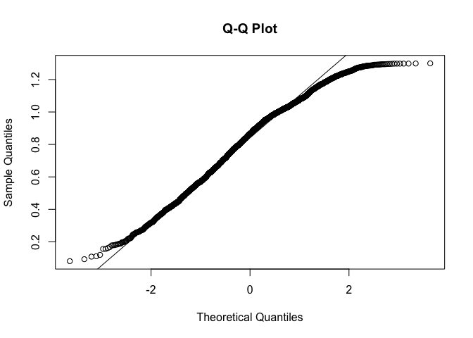

```r
# Create a Q-Q plot
qqnorm(Ast_Subset$Perihelion.Distance, main = "Q-Q Plot")

# Add a Q-Q line (e.g., line for the normal distribution)
qqline(Ast_Subset$Perihelion.Distance, distribution = qnorm)
```

## Data Visualization :

## Histogram plots to check the distribution

### Part 1: Checking Histograms for Distributions

#### Part 2.1 : Absolute Magnitude, Estimated Diameter (Min), Estimated Diameter (Max)

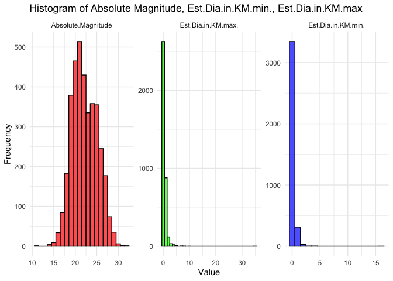

```r
library(ggplot2)
# Load the tidyr package
library(tidyr)

# Create a histogram for 'Absolute.Magnitude', 'Est.Dia.in.KM.min.', and 'Est.Dia.in.KM.max'
selected_columns_1 <- Ast_Subset[c('Absolute.Magnitude', 'Est.Dia.in.KM.min.', 'Est.Dia.in.KM.max.')]

# Reshape the data into long format
Ast_Subset_long_1 <- pivot_longer(selected_columns_1,
                                cols = everything(),
                                names_to = "Variable", values_to = "Value")

# Create the histogram
ggplot(Ast_Subset_long_1, aes(x = Value, fill = Variable, color = "black")) +
  geom_histogram(binwidth = 1.0, alpha = 0.7, position = "identity", show.legend = FALSE) +
  facet_wrap(~Variable, scales = "free") +
  labs(title = "Histogram of Absolute Magnitude, Est.Dia.in.KM.min., Est.Dia.in.KM.max", x = "Value", y = "Frequency") +
  scale_fill_manual(values = rainbow(length(unique(Ast_Subset_long_1$Variable))) ) +
  scale_color_manual(values = "black") +
  theme_minimal() +
  theme(legend.position = "right")
```

### Part 2 : Histograms for Velocity, Orbit Uncertainity, Jupiter Tisserand Invariant

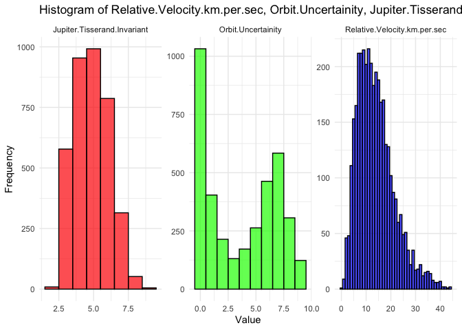

```r
# Create a histogram for 'Relative.Velocity.km.per.sec', 'Orbit.Uncertainity', and 'Jupiter.Tisserand.Invariant'
selected_columns_2 <- Ast_Subset[c('Relative.Velocity.km.per.sec', 'Orbit.Uncertainity', 'Jupiter.Tisserand.Invariant')]

# Reshape the data into long format
Ast_Subset_long_2 <- pivot_longer(selected_columns_2,
                                cols = everything(),
                                names_to = "Variable", values_to = "Value")

# Create the histogram
ggplot(Ast_Subset_long_2, aes(x = Value, fill = Variable, color = "black")) +
  geom_histogram(binwidth = 1.0, alpha = 0.7, position = "identity", show.legend = FALSE) +
  facet_wrap(~Variable, scales = "free") +
  labs(title = "Histogram of Relative.Velocity.km.per.sec, Orbit.Uncertainity, Jupiter.Tisserand.Invariant", x = "Value", y = "Frequency") +
  scale_fill_manual(values = rainbow(length(unique(Ast_Subset_long_2$Variable))) ) +
  scale_color_manual(values = "black") +
  theme_minimal() +
  theme(legend.position = "right")
```

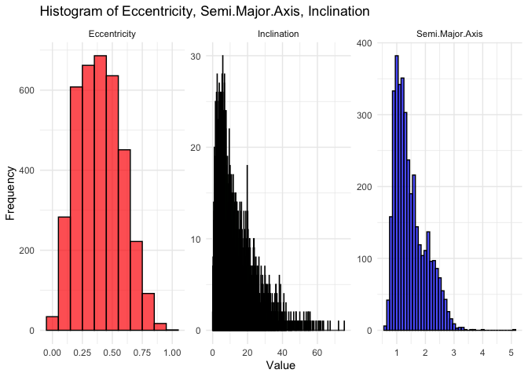

```r
# Create a histogram for 'Eccentricity', 'Semi.Major.Axis', and 'Inclination'
selected_columns_3 <- Ast_Subset[c('Eccentricity', 'Semi.Major.Axis', 'Inclination')]

# Reshape the data into long format
Ast_Subset_long_3 <- pivot_longer(selected_columns_3,
                                cols = everything(),
                                names_to = "Variable", values_to = "Value")

# Create the histogram
ggplot(Ast_Subset_long_3, aes(x = Value, fill = Variable, color = "black")) +
  geom_histogram(binwidth = 0.1, alpha = 0.7, position = "identity", show.legend = FALSE) +
  facet_wrap(~Variable, scales = "free") +
  labs(title = "Histogram of Eccentricity, Semi.Major.Axis, Inclination", x = "Value", y = "Frequency") +
  scale_fill_manual(values = rainbow(length(unique(Ast_Subset_long_3$Variable))) ) +
  scale_color_manual(values = "black") +
  theme_minimal() +
  theme(legend.position = "right")
```

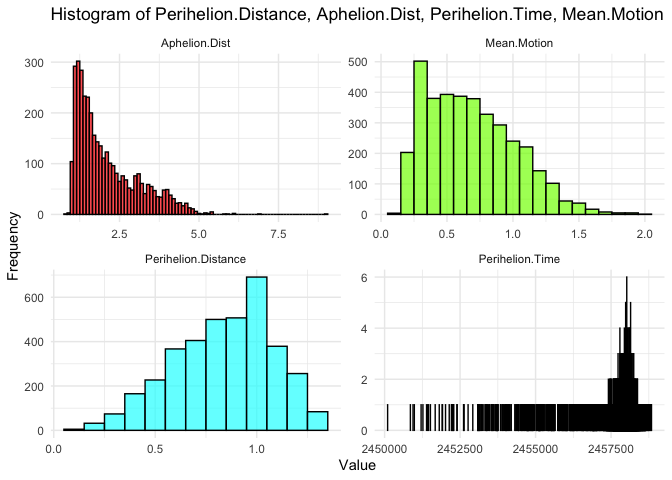

```r
# Create a histogram for 'Perihelion.Distance', 'Aphelion.Dist', 'Perihelion.Time', 'Mean.Motion'
selected_columns_4 <- Ast_Subset[c('Perihelion.Distance', 'Aphelion.Dist', 'Perihelion.Time', 'Mean.Motion')]

# Reshape the data into long format
Ast_Subset_long_4 <- pivot_longer(selected_columns_4,
                                cols = everything(),
                                names_to = "Variable", values_to = "Value")

# Create the histogram
ggplot(Ast_Subset_long_4, aes(x = Value, fill = Variable, color = "black")) +
  geom_histogram(binwidth = 0.1, alpha = 0.7, position = "identity", show.legend = FALSE) +
  facet_wrap(~Variable, scales = "free") +
  labs(title = "Histogram of Perihelion.Distance, Aphelion.Dist, Perihelion.Time, Mean.Motion", x = "Value", y = "Frequency") +
  scale_fill_manual(values = rainbow(length(unique(Ast_Subset_long_4$Variable))) ) +
  scale_color_manual(values = "black") +
  theme_minimal() +
  theme(legend.position = "right")
```

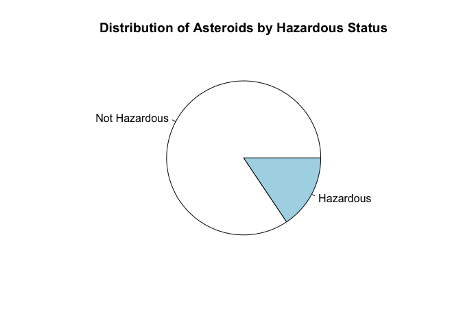

```r
# Create a pie chart for a binary categorical variable
counts <- table(Ast_Subset$Hazardous)

# Assign labels to the counts
labels <- c("Not Hazardous", "Hazardous")

# Create the pie chart
pie(counts, labels = labels, main = "Distribution of Asteroids by Hazardous Status")
```

When going to the distributions of the hazardous column. It is clearly visible that the Non-Hazardous Asteroids are more compared to Hazardous. The data is Asymmetrical. Considering the 3000 minimum rows rule, leveling/making data symmetrical is not a viable option right now.

** Null Hypothesis **: There is no significant difference in perihelion distance for hazardous and non-hazardous asteroids.** Alternate Hypothesis **: There is significant difference in perihelion distance for hazardous and non-hazardous asteroids.

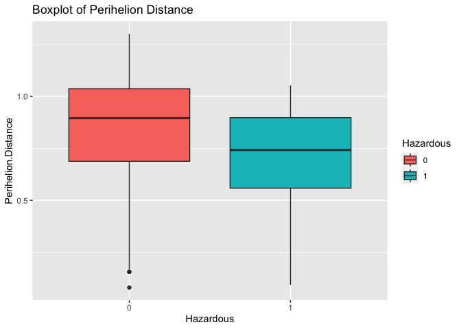

```r
ggplot(Ast_Subset, aes(Hazardous , Perihelion.Distance, group = Hazardous , fill = Hazardous)) + geom_boxplot() + labs(title="Boxplot of Perihelion Distance ")
```

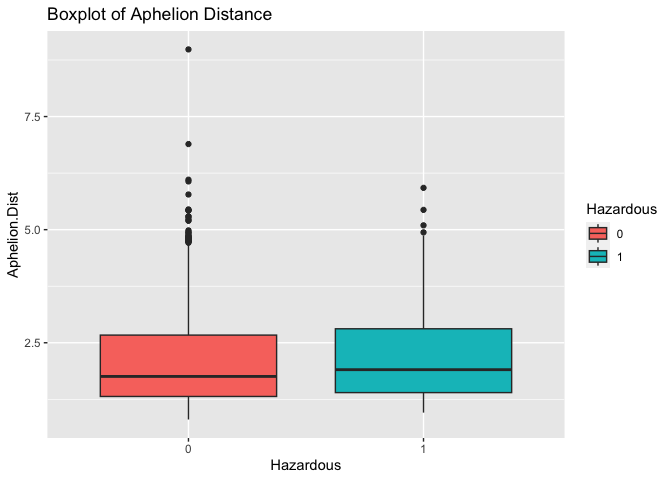

```r
ggplot(Ast_Subset, aes(Hazardous , Aphelion.Dist, group = Hazardous, fill = Hazardous)) + geom_boxplot() +labs(title="Boxplot of Aphelion Distance ")
```

```r
Per_Hazardous <- Ast_Subset$Perihelion.Distance[Ast_Subset$Hazardous == 1]
Per_Non_Hazardous <- Ast_Subset$Perihelion.Distance[Ast_Subset$Hazardous == 0]

Aph_Hazardous <- Ast_Subset$Aphelion.Dist[Ast_Subset$Hazardous == 1]
Aph_Non_Hazardous <- Ast_Subset$Aphelion.Dist[Ast_Subset$Hazardous == 0]



test_per <- t.test(Per_Hazardous, Per_Non_Hazardous)
test_aph <- t.test(Aph_Hazardous, Aph_Non_Hazardous)

test_per
test_aph
```

[output not shown]

Observation:

Perihelion Distance: There is an observable trend where hazardous asteroids tend to exhibit smaller perihelion distances when compared to their non-hazardous counterparts.

```r
# Install the following package (if not already)
# install.packages("randomForest")

library(randomForest)

# Splitting the dataset into predictors (X) excluding the target variable
X <- select(Ast_Subset, -c(Hazardous))
Y <- Ast_raw$Hazardous

# Fitting a Random Forest model to determine feature importance
set.seed(123)  # Setting a seed for reproducibility
rf_model <- randomForest(X, Y, ntree = 1000)

# Getting the feature importance
importance <- importance(rf_model)

# Printing importance
print(importance)
```

```
##                              MeanDecreaseGini
## Neo.Reference.ID                         50.1
## Name                                     50.3
## Absolute.Magnitude                       81.9
## Est.Dia.in.KM.min.                       79.8
## Est.Dia.in.KM.max.                       76.0
## Relative.Velocity.km.per.sec             59.7
## Orbit.Uncertainity                       35.1
## Jupiter.Tisserand.Invariant              46.4
## Eccentricity                             60.1
## Semi.Major.Axis                          47.1
## Inclination                             119.2
## Perihelion.Distance                     122.7
## Aphelion.Dist                            51.4
## Perihelion.Time                          45.8
## Mean.Motion                              46.3
```

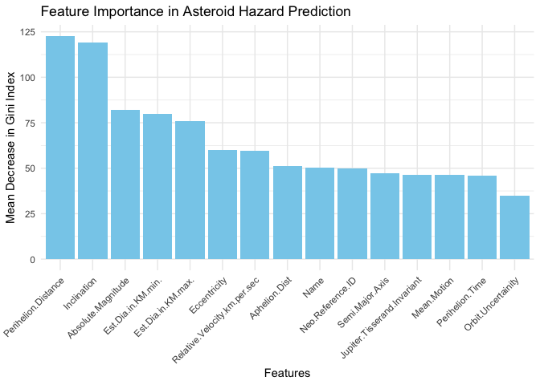

```r
library(ggplot2)

# Get feature importance as a data frame
importance_df <- as.data.frame(importance(rf_model))

# Create a custom feature importance plot
ggplot(importance_df, aes(x = reorder(rownames(importance_df), -MeanDecreaseGini), y = MeanDecreaseGini)) +
  geom_bar(stat = "identity", fill = "skyblue") +
  labs(x = "Features", y = "Mean Decrease in Gini Index") +
  theme_minimal() +
  theme(axis.text.x = element_text(angle = 45, hjust = 1)) +
  ggtitle("Feature Importance in Asteroid Hazard Prediction")
```

## Smart Question:PratiKsha Dange

**Is there any significant difference in the orbit uncertainty, Mean Motion, and inclination with a change in Perihelion Distance?**  
- Test: ANOVA Test .  
- Reason: Here we are examining the relationship between orbit uncertainty, mean motion, and inclination (which are likely numeric or continuous variables) and perihelion distance (also a numeric variable).

```r
# Perform ANOVA for 'OrbitUncertainty' with 'PerihelionDistance'
orbitU_perihelionDist_anova <- aov(`Orbit.Uncertainity` ~ `Perihelion.Distance`, data = Ast_raw)
summary(orbitU_perihelionDist_anova)
```

```
##                       Df Sum Sq Mean Sq F value  Pr(>F)
## Perihelion.Distance    1    381     381    39.4 3.9e-10 ***
## Residuals           3690  35756      10
## ---
## Signif. codes:  0 '***' 0.001 '**' 0.01 '*' 0.05 '.' 0.1 ' ' 1
```

```r
# Perform ANOVA for 'MeanMotion' with 'PerihelionDistance'
meanM_perihelionDist_anova <- aov(`Mean.Motion` ~ `Perihelion.Distance`, data = Ast_raw)
summary(meanM_perihelionDist_anova)
```

```
##                       Df Sum Sq Mean Sq F value Pr(>F)
## Perihelion.Distance    1    133   133.0    1777 <2e-16 ***
## Residuals           3690    276     0.1
## ---
## Signif. codes:  0 '***' 0.001 '**' 0.01 '*' 0.05 '.' 0.1 ' ' 1
```

```r
# Perform ANOVA for 'Inclination' with 'PerihelionDistance'
inclination_perihelionDist_anova <- aov(Inclination ~ `Perihelion.Distance`, data = Ast_raw)
summary(inclination_perihelionDist_anova)
```

```
##                       Df Sum Sq Mean Sq F value Pr(>F)
## Perihelion.Distance    1   1681    1681    13.9  2e-04 ***
## Residuals           3690 447526     121
## ---
## Signif. codes:  0 '***' 0.001 '**' 0.01 '*' 0.05 '.' 0.1 ' ' 1
```

**Test 1 - Orbit Uncertainty vs. Perihelion Distance:**

- Df (Degrees of Freedom): There is 1 degree of freedom associated with Perihelion Distance, and 3690 degrees of freedom for residuals.
- Sum Sq (Sum of Squares): The sum of squares for Perihelion Distance is 381, and for residuals, it’s 35756.
- Mean Sq (Mean Square): The mean square for Perihelion Distance is 381.
- F value: The F-statistic is 39.4.
- Pr(>F): The p-value is approximately 3.9e-10, which is extremely small.

**Interpretation:** In this test, the p-value (Pr(>F)) is very small (3.9e-10), which indicates that there is a statistically significant difference in “Orbit Uncertainty” with a change in “Perihelion Distance.” This suggests that “Perihelion Distance” has a significant impact on “Orbit Uncertainty.”

**Test 2 - Mean Motion vs. Perihelion Distance:**

- Df: 1 degree of freedom for Perihelion Distance and 3690 degrees of freedom for residuals.
- Sum Sq: The sum of squares for Perihelion Distance is 133, and for residuals, it’s 276.
- Mean Sq: The mean square for Perihelion Distance is 133.
- F value: The F-statistic is 1777.
- Pr(>F): The p-value is less than 2e-16, which is extremely small.

**Interpretation:** In this test, the p-value is also very small (much less than 0.001), indicating a highly significant difference in “Mean Motion” with a change in “Perihelion Distance.” Thus, “Perihelion Distance” significantly affects “Mean Motion.”

**Test 3 - Inclination vs. Perihelion Distance:**

- Df: 1 degree of freedom for Perihelion Distance and 3690 degrees of freedom for residuals.
- Sum Sq: The sum of squares for Perihelion Distance is 1681, and for residuals, it’s 447526.
- Mean Sq: The mean square for Perihelion Distance is 1681.
- F value: The F-statistic is 13.9.
- Pr(>F): The p-value is 2e-04, which is relatively small.

**Interpretation:** In this test, the p-value (Pr(>F)) is smaller than 0.05, indicating a significant difference in “Inclination” concerning changes in “Perihelion Distance.” It implies that “Perihelion Distance” has a statistically significant effect on “Inclination,” though the significance is not as strong as in the previous tests.

In summary, based on these ANOVA tests, it appears that “Perihelion Distance” has a significant impact on “Orbit Uncertainty,” “Mean Motion,” and “Inclination,” with “Mean Motion” having the most substantial effect, followed by “Orbit Uncertainty” and then “Inclination.” The p-values for all three tests suggest that the relationships are statistically significant.